# R Notebook

# Risks

## Possion Process & Linear Model

```r
df <- read_csv("raw/prcp.csv")
df <- read_csv("raw/prcp.csv")
df %>%
  mutate(year = format(date, "%Y")) %>%
  dplyr::select(date, year, prcp) %>%
  group_by(year) %>%
  filter(prcp != 0) %>%
  summarise(rain_days = length(prcp)) -> rainDays
```

```r
yearDays %>%
  filter(year_days < 365)
```

| year | year_days |
| --- | --- |
| 2018 | 334 |
| 2021 | 211 |

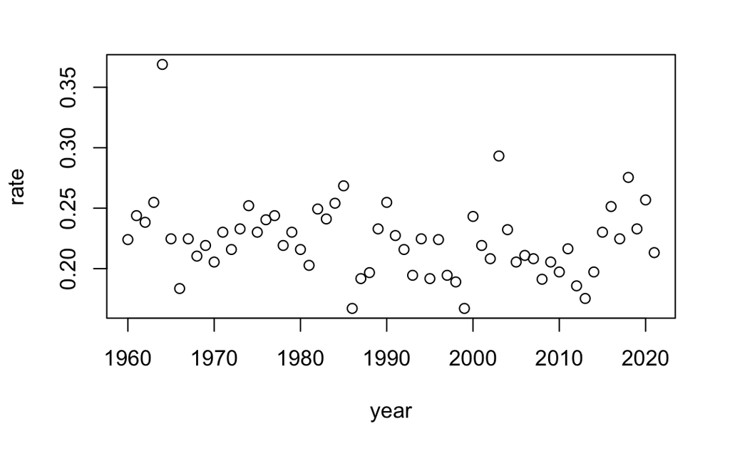

```r
rainDays %>% left_join(yearDays, by = "year") %>%
  mutate(rate = rain_days/year_days) %>%
  with(plot(x = year, y = rate))
```

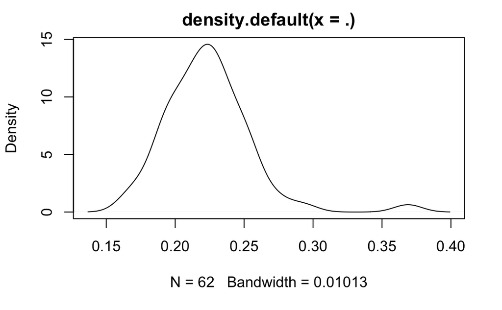

```r
rainDays %>% left_join(yearDays, by = "year") %>%
  mutate(rate = rain_days/year_days) %>%
  pull(rate) %>%
  density() %>%
  plot()
```

```r
rainDays %>% left_join(yearDays, by = "year") %>%
  mutate(rate = rain_days/year_days) %>%
  filter(year <= 2015) %>%
  mutate(year = as.numeric(year)) -> data
length(data$year)
```

```
[1] 56
```

```r
sd(data$rate)
```

```
[1] 0.03215555
```

```r
mean(data$rate)
```

```
[1] 0.2217114
```

```r
lm(data = data, rate ~ year) -> mod.lm
summary(mod.lm)
```

```
Call:
lm(formula = rate ~ year, data = data)

Residuals:
      Min        1Q    Median        3Q       Max
-0.055671 -0.017696 -0.002189  0.011829  0.130179

Coefficients:
              Estimate Std. Error t value Pr(>|t|)
(Intercept)  1.6562487  0.4962413   3.338  0.00154 **
year        -0.0007218  0.0002497  -2.891  0.00552 **
---
Signif. codes:  0 ‘***’ 0.001 ‘**’ 0.01 ‘*’ 0.05 ‘.’ 0.1 ‘ ’ 1

Residual standard error: 0.0302 on 54 degrees of freedom
Multiple R-squared:  0.134, Adjusted R-squared:  0.118
F-statistic: 8.357 on 1 and 54 DF,  p-value: 0.005523
```

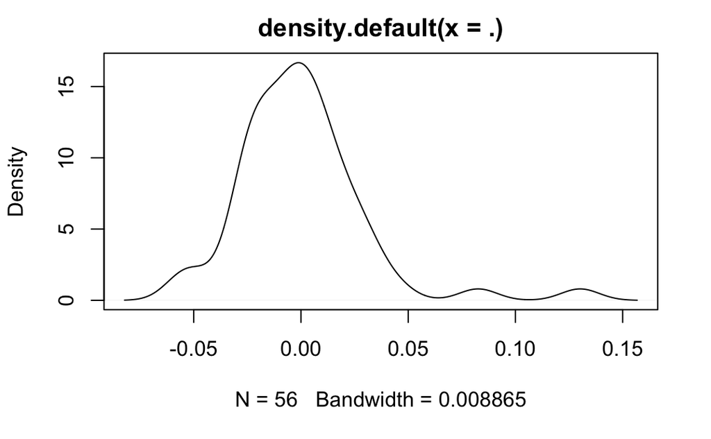

```r
residuals(mod.lm) %>% density() %>% plot
```

In this statistically model you assume the change of rain is normally distributed. But in this case residual is slightly tiled towards left…

## Expotential

Signs that percepitation is exponentially distributed.

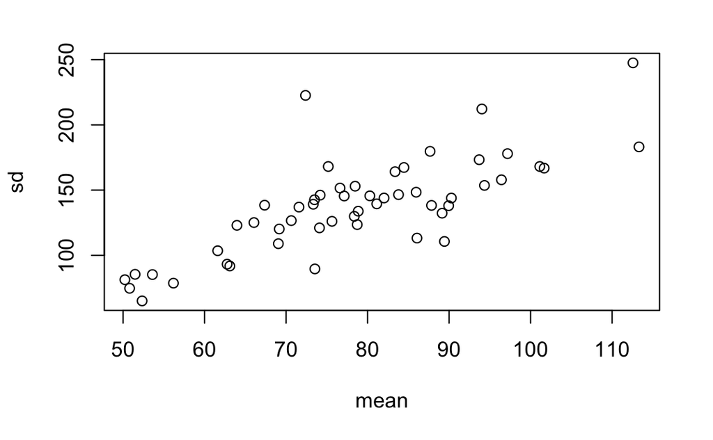

This should be enough to prove the potential distribution because mean and is correlated??

[figure not shown]

```r
df %>%
  mutate(year = format(date, "%Y")) %>%
  dplyr::select(date, year, prcp) %>%
  group_by(year) %>%
  filter(prcp != 0) %>%
  filter(year <= 2012) %>%
  pull(prcp) %>%
  hist(breaks = 1000, freq = TRUE) -> hist
names(hist)
hist$density %>% length()
hist$mids %>% length()

x <- hist$mids
y <- hist$density

data.frame(x, y) -> seed
seed[sample(nrow(seed), 750),]

library(drc)
library(nlme)

update.packages("drc")
seed %>%
  filter( x <= 400) -> tailess

mod.exd <- drm(y ~ x, fct = EXD.2(), data = seed)
mod <- drm(y ~ x, fct = AR.2(), data = seed)
```

plot hist

```r
with(hist, plot(mids, density, pch = ".", xlim = c(0, 200)))
sum(hist$density)
```

[output not shown]

plot model

```r
plot(x = seed$x, y = fitted(mod.exd), type = "l", col = "blue", xlim = c(0,300))
lines(x = seed$x, y = tailess$y, type = "p", col = alpha("black", 0.5))
```

[output not shown]

```r
model <- drm(y ~ log(x), fct = EXD.2(), data = seed)
```

```r
plot(x = seed$x, y = fitted(model), type = "l", col = "blue", xlim = c(0, 300))
lines(x = seed$x, y = seed$y, type = "p", col = alpha("black", 0.5))
```

[output not shown]

So you it proves log(x) is exponentially distributed?

```r
summary(model)
```

[output not shown]

f(x) = c + (d-c)((-x/e))

0.7828405 = 1/e = Ighag = 10* 0.07740550 I think it is something to do with the scale x needs to be multiplied by 10

or log x needs to be multiplied by 10

so we derive this function perhaps?? 10 * log (x) ~ exponential() and then give parameter a value 0.07740550..

Hist density is a function??

```r
x = log()
d = 0.07740550
e = 1.27739939

k <- 1/e/d  #10.1135
log(1000)*k

1 - pexp(log(1000)*k, d)
```

[output not shown]

compare this result to from counting raindays

```r
df %>%
  mutate(year = format(date, "%Y")) %>%
  dplyr::select(date, year, prcp) %>%
  group_by(year) %>%
  filter(prcp != 0) %>%
  pull(prcp) %>%
  length()

%>%
  filter(year <= 2012) %>%
  filter(prcp >= 1000)

%>%
  pull(prcp)  %>%
  length()


13/5025

x <- hist$mids
y <- hist$count

data.frame(x, y) -> seed
seed[seed$x >= 1000,]$y

sum(hist$counts)
length(df$prcp)
```

0.002587065 0.25% percent…

compares to probability density estimate: 0.004482068

0.4% probability that in any rain day a rain would exceed 10cm

# Prediction

```r
#library(forecast)
g <- df %>%
  ggplot(aes(x = date, y = prcp)) +
  geom_line(color = "blue") +
  theme(panel.border = element_blank(),
          panel.grid.major = element_blank(),
          panel.grid.minor = element_blank(),
          panel.background = element_rect(fill = "#fafafa"),
          plot.background = element_rect(fill = "white")
        )
ggplotly(g)
```

[output not shown]